# An Exploration of Prosper Loan Data by Matthew Long

In this report, I will analyze a data set of loan details from the the loan provider Prosper. This data set, last updated March 2014, contains over 100,000 loans with more than 80 variables for each loan. The data set can be downloaded [here](https://www.google.com/url?q=https://s3.amazonaws.com/udacity-hosted-downloads/ud651/prosperLoanData.csv&sa=D&ust=1519089344558000&usg=AFQjCNGvTYnqWqji0_vW42FekVfRBSGviw).

# Univariate Plots Section

```
## 'data.frame':    113937 obs. of  81 variables:
##  $ ListingKey                         : Factor w/ 113066 levels "00003546482094282EF90E5",..: 7180 7193 6647 6669 6686 6689 6699 6706 6687 6687 ...
##  $ ListingNumber                      : int  193129 1209647 81716 658116 909464 1074836 750899 768193 1023355 1023355 ...
##  $ ListingCreationDate                : Factor w/ 113064 levels "2005-11-09 20:44:28.847000000",..: 14184 111894 6429 64760 85967 100310 72556 74019 97834 97834 ...
##  $ CreditGrade                        : Factor w/ 9 levels "","A","AA","B",..: 5 1 8 1 1 1 1 1 1 1 ...
##  $ Term                               : int  36 36 36 36 36 60 36 36 36 36 ...
##  $ LoanStatus                         : Factor w/ 12 levels "Cancelled","Chargedoff",..: 3 4 3 4 4 4 4 4 4 4 ...
##  $ ClosedDate                         : Factor w/ 2803 levels "","2005-11-25 00:00:00",..: 1138 1 1263 1 1 1 1 1 1 1 ...
##  $ BorrowerAPR                        : num  0.165 0.12 0.283 0.125 0.246 ...
##  $ BorrowerRate                       : num  0.158 0.092 0.275 0.0974 0.2085 ...
##  $ LenderYield                        : num  0.138 0.082 0.24 0.0874 0.1985 ...
##  $ EstimatedEffectiveYield            : num  NA 0.0796 NA 0.0849 0.1832 ...
##  $ EstimatedLoss                      : num  NA 0.0249 NA 0.0249 0.0925 ...
##  $ EstimatedReturn                    : num  NA 0.0547 NA 0.06 0.0907 ...
##  $ ProsperRating..numeric.            : int  NA 6 NA 6 3 5 2 4 7 7 ...
```

[output cut: 67 more lines]

```
##                    ListingKey     ListingNumber
##  17A93590655669644DB4C06:     6   Min.   :      4
##  349D3587495831350F0F648:     4   1st Qu.: 400919
##  47C1359638497431975670B:     4   Median : 600554
##  8474358854651984137201C:     4   Mean   : 627886
##  DE8535960513435199406CE:     4   3rd Qu.: 892634
##  04C13599434217079754AEE:     3   Max.   :1255725
##  (Other)                :113912
##                     ListingCreationDate  CreditGrade         Term
##  2013-10-02 17:20:16.550000000:     6          :84984   Min.   :12.00
##  2013-08-28 20:31:41.107000000:     4   C      : 5649   1st Qu.:36.00
##  2013-09-08 09:27:44.853000000:     4   D      : 5153   Median :36.00
##  2013-12-06 05:43:13.830000000:     4   B      : 4389   Mean   :40.83
##  2013-12-06 11:44:58.283000000:     4   AA     : 3509   3rd Qu.:36.00
##  2013-08-21 07:25:22.360000000:     3   HR     : 3508   Max.   :60.00
##  (Other)                      :113912   (Other): 6745
##                  LoanStatus                  ClosedDate
##  Current              :56576                      :58848
##  Completed            :38074   2014-03-04 00:00:00:  105
##  Chargedoff           :11992   2014-02-19 00:00:00:  100
##  Defaulted            : 5018   2014-02-11 00:00:00:   92
##  Past Due (1-15 days) :  806   2012-10-30 00:00:00:   81
##  Past Due (31-60 days):  363   2013-02-26 00:00:00:   78
##  (Other)              : 1108   (Other)            :54633
##   BorrowerAPR       BorrowerRate     LenderYield
##  Min.   :0.00653   Min.   :0.0000   Min.   :-0.0100
##  1st Qu.:0.15629   1st Qu.:0.1340   1st Qu.: 0.1242
##  Median :0.20976   Median :0.1840   Median : 0.1730
##  Mean   :0.21883   Mean   :0.1928   Mean   : 0.1827
##  3rd Qu.:0.28381   3rd Qu.:0.2500   3rd Qu.: 0.2400
##  Max.   :0.51229   Max.   :0.4975   Max.   : 0.4925
##  NA's   :25
##  EstimatedEffectiveYield EstimatedLoss   EstimatedReturn
##  Min.   :-0.183          Min.   :0.005   Min.   :-0.183
##  1st Qu.: 0.116          1st Qu.:0.042   1st Qu.: 0.074
##  Median : 0.162          Median :0.072   Median : 0.092
##  Mean   : 0.169          Mean   :0.080   Mean   : 0.096
##  3rd Qu.: 0.224          3rd Qu.:0.112   3rd Qu.: 0.117
##  Max.   : 0.320          Max.   :0.366   Max.   : 0.284
##  NA's   :29084           NA's   :29084   NA's   :29084
```

[output cut: 193 more lines]

```
##  Min.   :    0.00                Min.   :0.7000   Min.   : 0.00000
##  1st Qu.:    0.00                1st Qu.:1.0000   1st Qu.: 0.00000
##  Median :    0.00                Median :1.0000   Median : 0.00000
##  Mean   :   25.14                Mean   :0.9986   Mean   : 0.04803
##  3rd Qu.:    0.00                3rd Qu.:1.0000   3rd Qu.: 0.00000
##  Max.   :21117.90                Max.   :1.0125   Max.   :39.00000
##
##  InvestmentFromFriendsCount InvestmentFromFriendsAmount   Investors
##  Min.   : 0.00000           Min.   :    0.00            Min.   :   1.00
##  1st Qu.: 0.00000           1st Qu.:    0.00            1st Qu.:   2.00
##  Median : 0.00000           Median :    0.00            Median :  44.00
##  Mean   : 0.02346           Mean   :   16.55            Mean   :  80.48
##  3rd Qu.: 0.00000           3rd Qu.:    0.00            3rd Qu.: 115.00
##  Max.   :33.00000           Max.   :25000.00            Max.   :1189.00
##
```

As we can see, we have 81 variables of a variety of types, including floats, integers, and dates, among others. Let’s dive into univariate analysis of some of these variables to see what we can learn about the data set.

```
##
##              Cancelled             Chargedoff              Completed
##                      5                  11992                  38074
##                Current              Defaulted FinalPaymentInProgress
##                  56576                   5018                    205
##   Past Due (>120 days)   Past Due (1-15 days)  Past Due (16-30 days)
##                     16                    806                    265
##  Past Due (31-60 days)  Past Due (61-90 days) Past Due (91-120 days)
##                    363                    313                    304
```

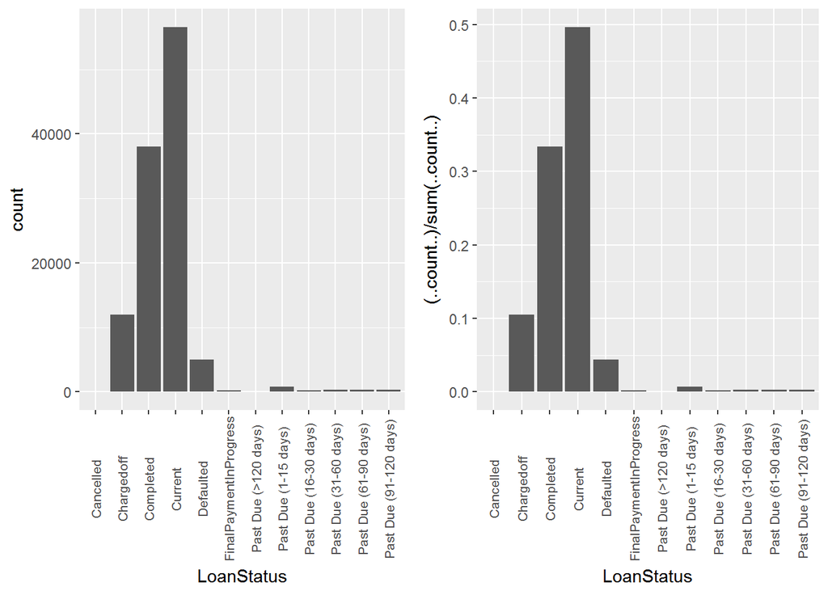

Looking at the `LoanStatus` variable, we see that a plurality of the loans are in the “Current” state, with ~57k loans (~50% of the data set) falling in that category. The next most common state is “Completed” with 38k loans or ~35% of the loans in the data set. Finally, another thing to note is there are very few loans in a “Canceled” state (only 5 out of 114k loans).

```
##
##     1     2     3     4     5     6     7     8     9    10    11
##   992  5766  7642 12595  9813 12278 10597 12053  6911  4750  1456
```

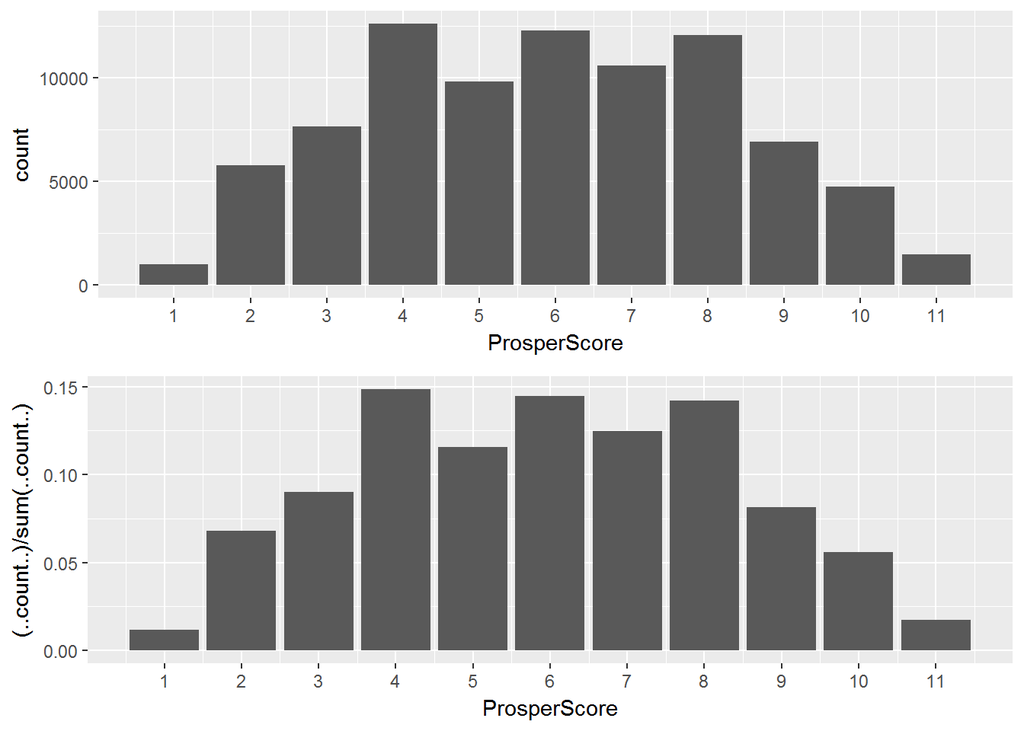

We can see that the `ProsperScore` is fairly well distributed with representation across from many of the different scores. The only concern here is that 1456 loans have a score of 11, whereas the variable dictionary asserted that the scale was from 1-10. Let’s take a look at a few of the loans with a score of 11 to see if we can see anything odd going on:

```
##                  ListingKey ListingNumber           ListingCreationDate
## 10  0F043596202561788EA13D5       1023355 2013-12-02 10:43:39.117000000
## 70  0F37360159310530849DA23       1162592 2014-01-25 12:07:54.537000000
## 159 108E36027739898797E47EC       1202850 2014-02-12 16:31:25.340000000
## 225 2F293599751524472C82DEA       1130508 2014-01-10 07:24:44.853000000
## 237 11D335932344051959C94C6        973657 2013-11-02 01:29:09.810000000
## 278 2EFC36028887817232507BC       1220331 2014-02-18 12:59:08.680000000
##     CreditGrade Term LoanStatus ClosedDate BorrowerAPR BorrowerRate
## 10                36    Current                0.07620       0.0629
## 70                60    Current                0.13636       0.1139
## 159               36    Current                0.09469       0.0809
## 225               36    Current                0.13799       0.1099
## 237               36    Current                0.06726       0.0605
## 278               60    Current                0.15868       0.1355
##     LenderYield EstimatedEffectiveYield EstimatedLoss EstimatedReturn
```

[output cut: 174 more lines]

It’s not clear what, if anything, might be wrong with these loans to cause this issue. In order to be save, let’s remove them from our data set and look at our plots again:

```r
loans <-subset(loans,loans$ProsperScore<=10)
```

```
##
##     1     2     3     4     5     6     7     8     9    10
##   992  5766  7642 12595  9813 12278 10597 12053  6911  4750
```

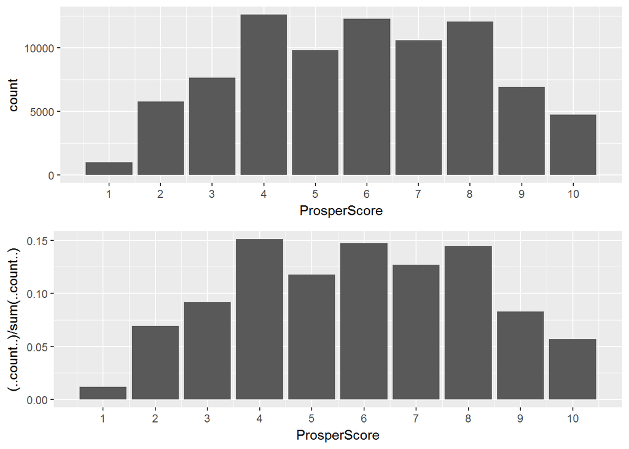

Great. That seems to have taken care of the issue. Next, let’s look at what could be considered a negative variable for loan approval: the amount of deliquent dollars at the time the credit profile was pulled (`AmountDelinquent`).

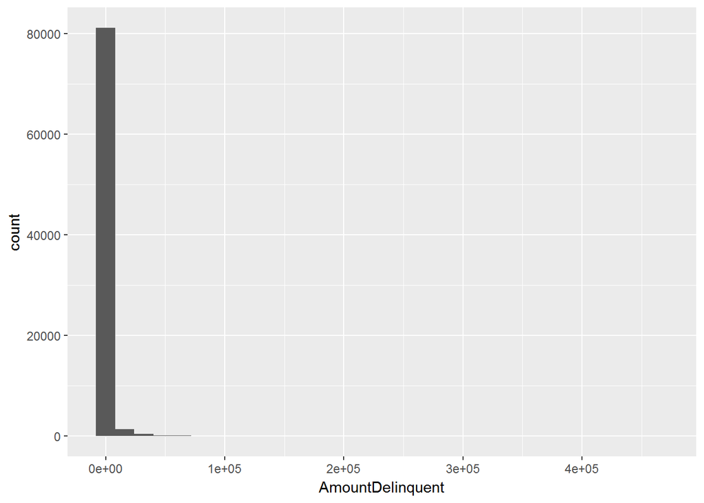

We can see that the vast majority of the group of data is clustered around zero, but the default binwidths are so large and the length of the x-axis so long that it leads me to believe something might be going wrong. Let’s look at a quantile table of this variable to see if we can find anything strange.

```
##     0%    10%    20%    30%    40%    50%    60%    70%    80%    90%
##      0      0      0      0      0      0      0      0      0    204
##   100%
## 463881
```

We see that, unsurprisngly, 80+% of the dataset had no delinquent dollars at the time the loan was initiated. However, at the very far-right of our distribution, we see that one loan supposedly had $464k in delinquent dollars! Let’s look at a more granular distribution of quantiles near the top to see if this is common or an isolated issue.

```
##       90%       91%       92%       93%       94%       95%       96%
##    204.00    320.00    500.00    776.00   1289.00   2175.40   3743.44
##       97%       98%       99%      100%
##   6786.60  12128.28  23985.12 463881.00
```

Looking at the quantiles, even the 99th percentile is $24k, which, although high, is nowhere near as high as $464k. This leads me to believe that data value is an error, so I will exclude all data points where the delinquent dollar amount exceeds $25k, and replot the data, this time using log transformations since the data is so right-skewed.

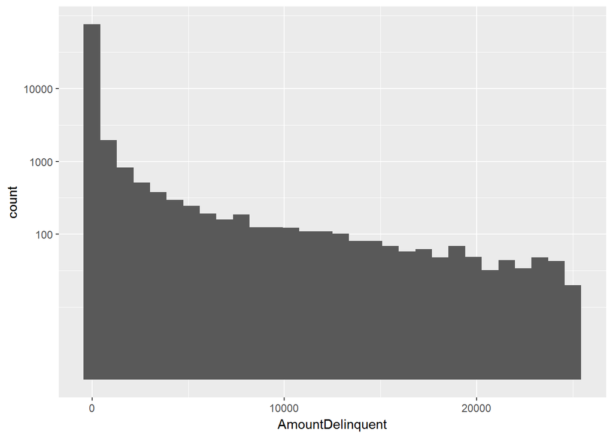

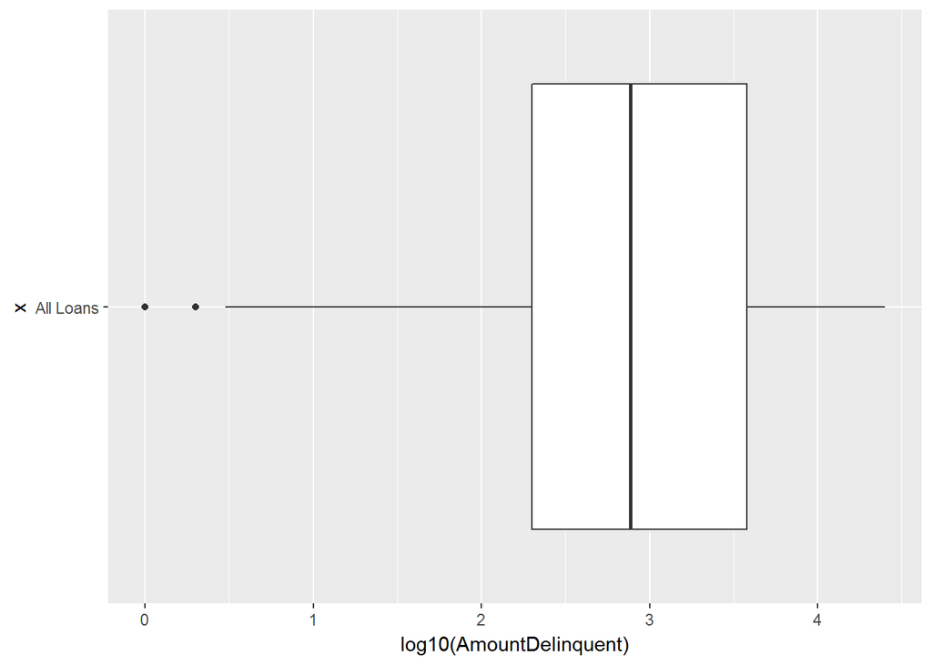

Since so much of the data is centered around `0`, using log transformations allows us to more easily see the shape of the two distributions. In the first plot, we see a much more linear relationship between `log10(count)` and `AmountDelinquent`. In the second plot, taking `log10(AmountDelinquent)` makes it much easier to visualize the spread of data about the mean.

Now let’s take a look at the origination amount of the loan (`LoanOriginalAmount`).

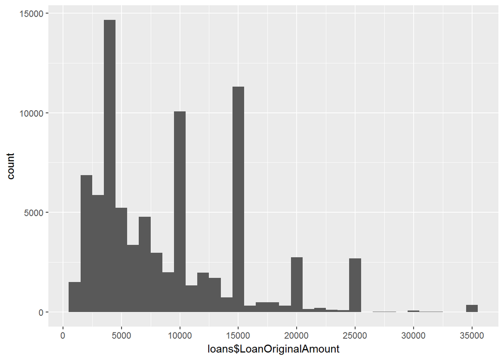

```
##
##  4000 15000 10000  2000  5000  3000 20000 25000  7000  7500
## 13024 11155  9625  4498  4127  3382  2685  2678  2257  2154
```

Using binwidths of 1000, we can see what the most common approximate loan amounts are. The number one most common loan amount is around $4k. After the data set contains a number of loans around $10k, $15k, $20k, and $25k. Let’s look at the distribution by loan type to see if anything in particular is contributing to the majority of the clustering around these round numbers:

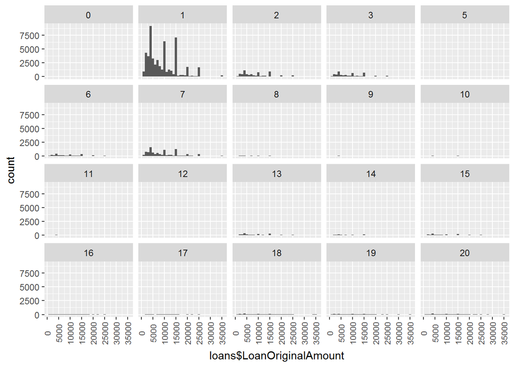

It looks like the most common loans are of the type 1, which corresponds to “Debt Consolidation.” Additionally, the peaks of the overall data set correspond with the peaks from this loan type. It’s possible that loan applicants approximate their total loan balances and round to the nearest $5k when applying for a debt consolidation loan.

Next, let’s take a look at the credit score of loan recipients. Presently, the data set has two credit score variables: `CreditScoreRangeLower` and `CreditScoreRangeUpper`. For simplicity, let’s create a new field, `CreditScoreRangeMid`, that is the average of the two provided fields and plot the result:

```r
loans$CreditScoreRangeMid <-
  (loans$CreditScoreRangeLower + loans$CreditScoreRangeUpper)/2.0
```

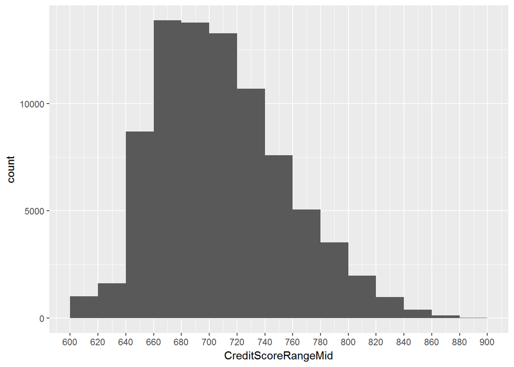

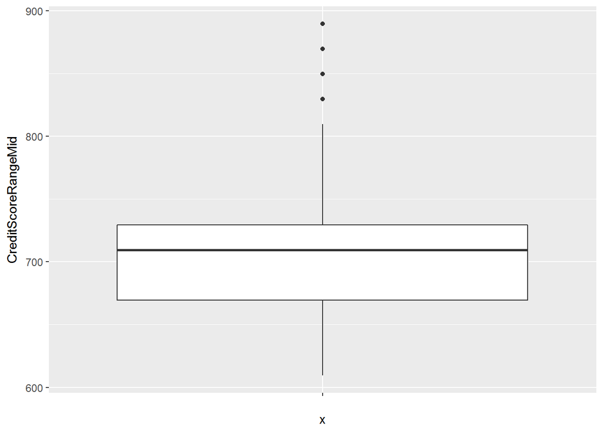

Finally, I’m curious to learn more about the distribution of loan origination amount divided by monthly income, so let’s create a new variable that captures that and plot the results.

```r
loans$LoanAmtPerMonthIncome <-
  (loans$LoanOriginalAmount)/(loans$StatedMonthlyIncome)
```

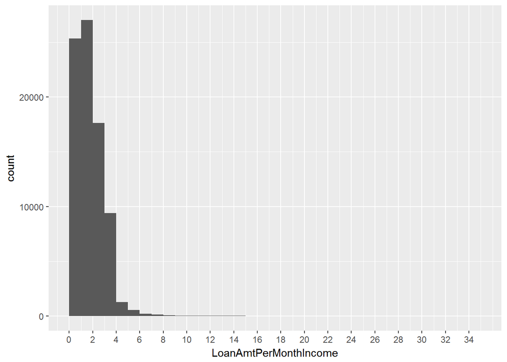

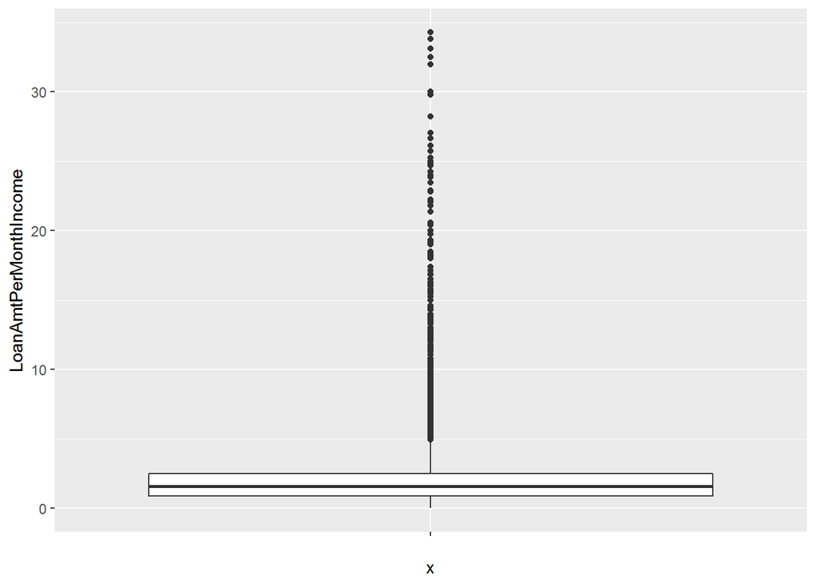

From the histogram and boxplot, we see the bulk of the ratios fall between 0 and 3, whereas a ratio above 5 is an outlier. This is unsurprising as I would expect the loan origination amount would not drastically exceed the borrower’s ability to pay as demonstrated by his or her monthly income.

Next, let’s look at the distribution of employment status, which is a categorical variable:

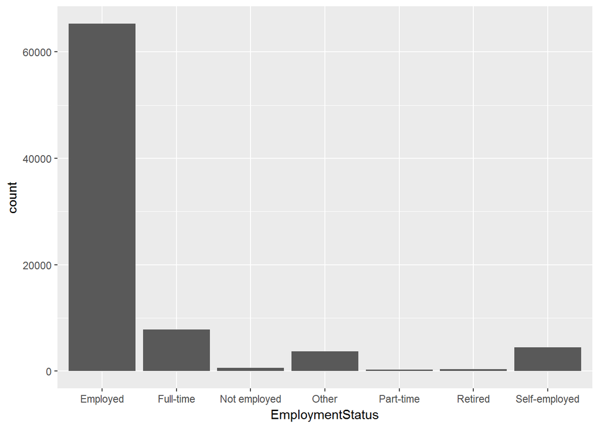

It looks like the majority of borrowers are employed, which is unsurprising. The most interesting thing about this variable is that there are options for employed, full-time, and part-time. Without seeing the actual form, it’s hard to say why all three of these categories can exist together in the same data set.

Next, let’s look at `Term` and `BorrowerAPR`:

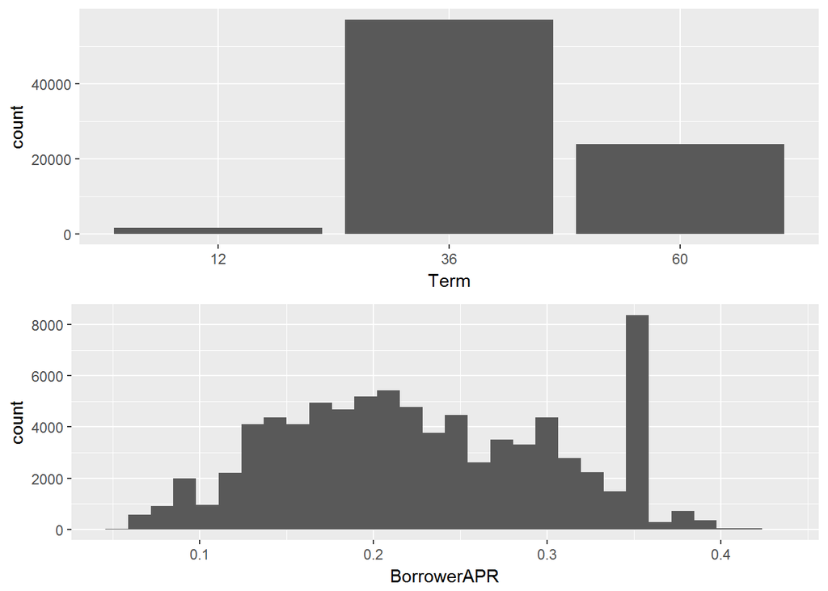

It looks like `Term` is a factor with three values: 12, 36, and 60, with very few loans featuring a term of 12. On the other hand, `BorrowerAPR` is a continuous variable with fairly symmetric distribution with the exception of a large spike near 0.35.

Finally, let’s turn our attention to `IncomeRange`:

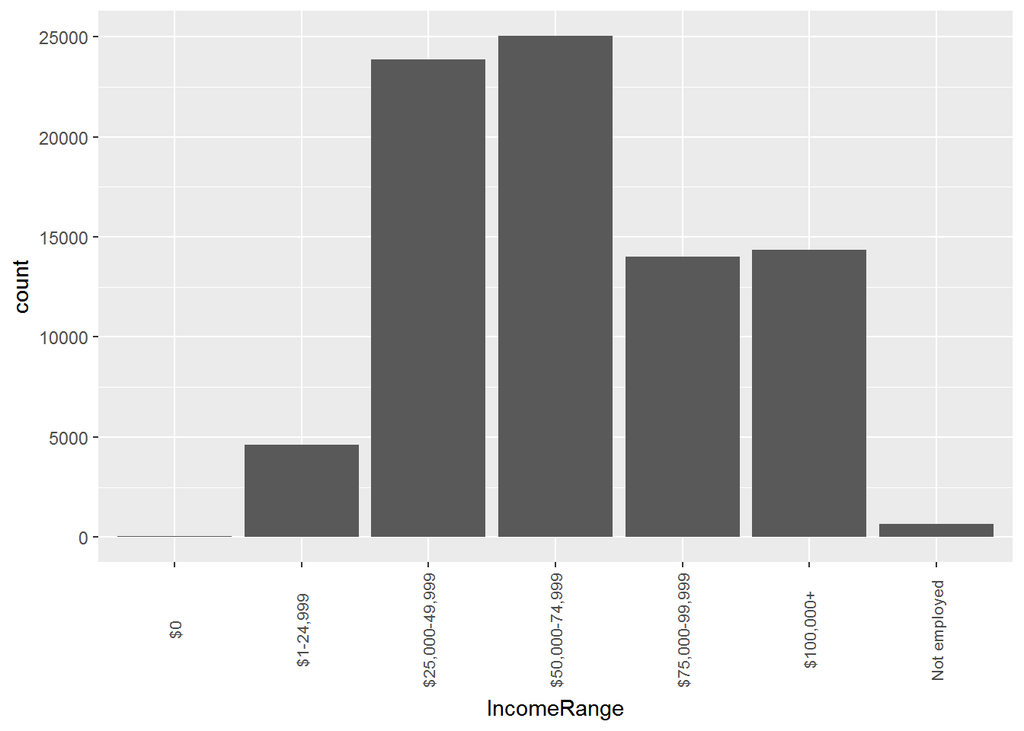

Looking at `IncomeRange`, we see that the range of $50-75k is most common, closely followed by $25-50k. What’s interesting is there are actually more borrows in the income range >$100k than between $75-100k. If the data were more granular, we could learn more about the distribution of income ranges above $100k, but unfortunately we’ll have to make do with what we have.

# Univariate Analysis

### What is the structure of your dataset?

After the data cleaning detailed above, my data set has 83k observations across 83 variables. Some of the variables are categorical data (e.g., `IncomeRange`), whereas some of the variables are continuous numerical data (e.g., `AmountDelinquent`).

### What is/are the main feature(s) of interest in your dataset?

The things I am most interested in are the attributes of the borrow at the time the loan was generated, the purpose of the loan, and how Prosper scored the borrowers.

### What other features in the dataset do you think will help support your investigation into your feature(s) of interest?

I think the above features will be sufficient in helping me understand the data. That said, I may discover other features that I want to explore as part of my exploratory data analysis.

### Did you create any new variables from existing variables in the dataset?

Yes, I created two variables. First, I created `CreditScoreRangeMid`, which is the midpoint of the lower- and upper-bound credit score ranges provided in the data set. Secondly, I calculated the ratio of loan origination amount to stated monthly income, or `LoanAmtPerMonthIncome`.

### Of the features you investigated, were there any unusual distributions? Did you perform any operations on the data to tidy, adjust, or change the form of the data? If so, why did you do this?

Yes, I did do some data cleaning as part of this exercise. Fist, I ran into some issues with `ProsperScore`, which fell outside the range indicated by the data dictionary. Second, I had to remove a clear outlier from `AmountDelinquent`. Third, while calculating the ratio of loan amount to stated monthly income, I learned that many records had a value of zero for stated monthly income, resulting in a ratio equal to infinity. Finally, when plotting IncomeRange, I learned the factors were not yet ordered, and had to make that change.

# Bivariate Plots Section

First, let’s take a look at how `ProsperScore` and `CreditScoreRangeMid` relate:

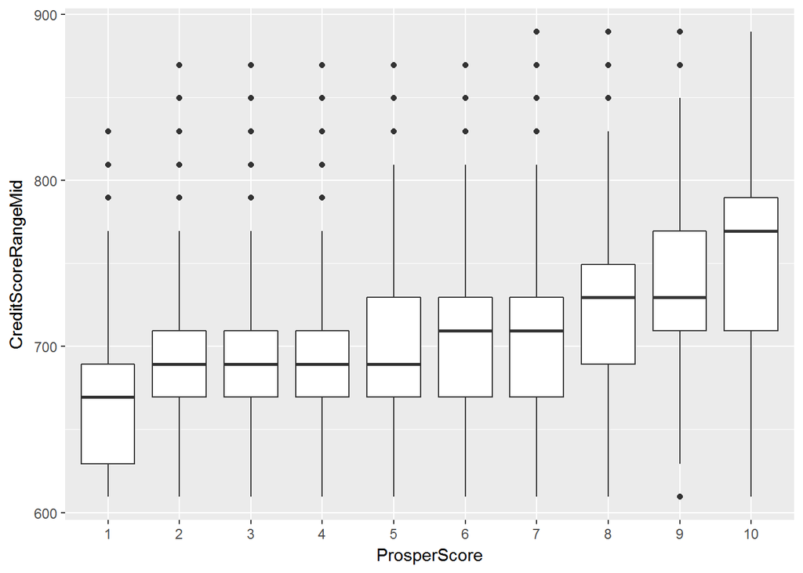

Given that `ProsperScore` is a discrete variable, it doesn’t make much sense to look at it as a scatterplot. Instead, a series of boxplots provides better visibility into the relationship. As we see, the mean credit score increases as the Prosper score increases.

Next, let’s look at how `AmountDelinquent` varies with `ProspectScore` and `CreditScoreRangeMid`:

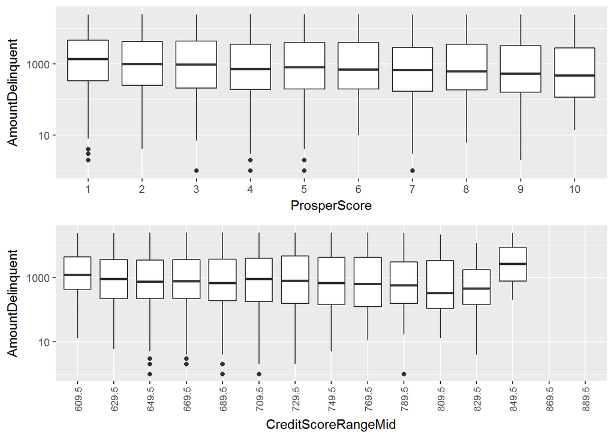

First, we need to conduct a log transformation on `AmountDelinquent`. Focusing on `ProsperScore`, `AmountDelinquent` seems to decrease as `ProsperScore` increases, which makes sense intuitively. Focusing on `CreditScoreRangeMid`, there seems also seems to be a downward trend in `log(AmountDelinquent)` as credit score increases, albeit with some noise in in the “849.5” bucket.

Next, let’s look at how `LoanOriginationAmount` varies with `log(AmountDelinquent)`:

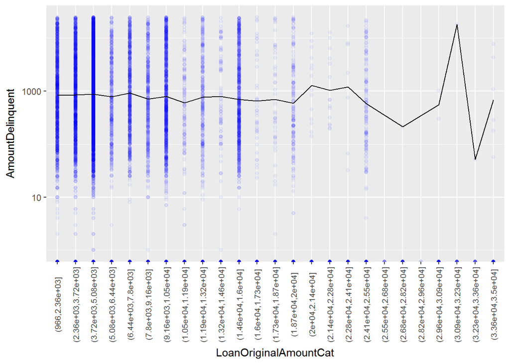

Notably, we need to bucket the `LoanOriginalAmount` into a reasonable number of categories (in this case, 25) in order to solve for the bias/variance trade-off. Following that transformation, we can see there’s no discernable linear relationship between the original loan amount and delinquent amount.

To get an overview of the data, we can run `ggpairs()` to see how each of the variables we’ve explored fit together:

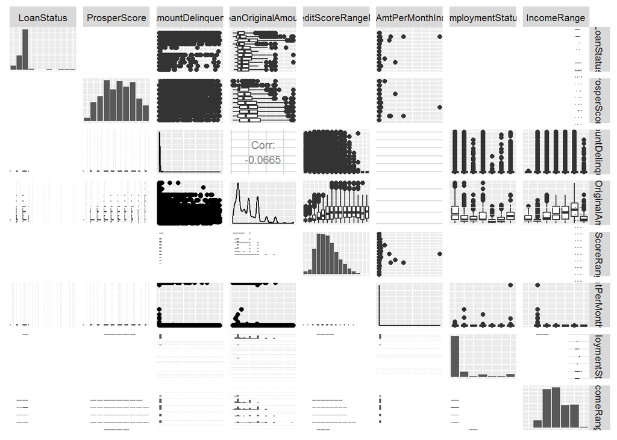

Reviewing the plots, a few trends stand out. First, `LoanOriginalAmount` tends to increase as `CreditScoreRangeMid` increases. Additionally, `LoanOriginalAmount` increases as `IncomeRange` increases. Finally, we see there is a negative correlation between `LoanOriginalAmount` and `AmountDelinquent`, although the correlation is weak (-0.06).

Let’s add a few other continuous variables to see if any other correlations emerge, including `Term`, `BorrowerAPR`, `EstimatedReturn`, `EmploymentStatusDuration`, and `RevolvingCreditBalance`:

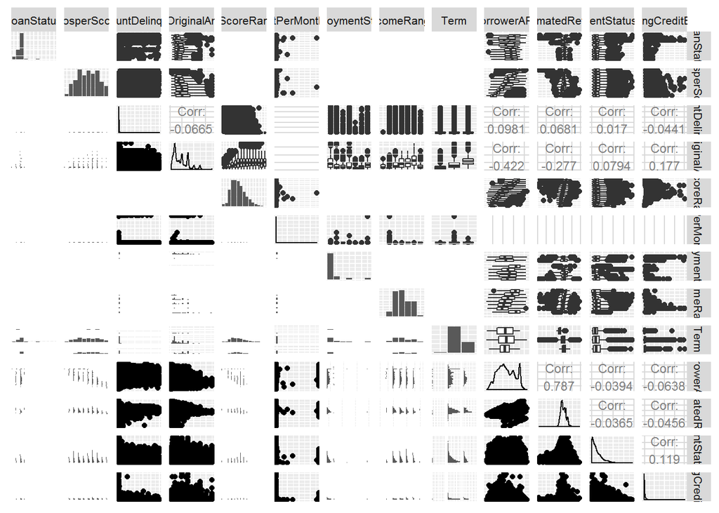

# Bivariate Analysis

### Talk about some of the relationships you observed in this part of the investigation. How did the feature(s) of interest vary with other features in the dataset?

As discussed previously, `LoanOriginalAmount` tends to increase as `CreditScoreRangeMid` increases. Additionally, `LoanOriginalAmount` increases as `IncomeRange` increases.

### What was the strongest relationship you found?

The strongest relationship I found was between `EstimatedReturn` and `BorrowerAPR`, which a correlation of 0.787.

# Multivariate Plots Section

First, let’s see how the relationship between `LoanOriginalAmount` and `Term` varies with `IncomeRange`:

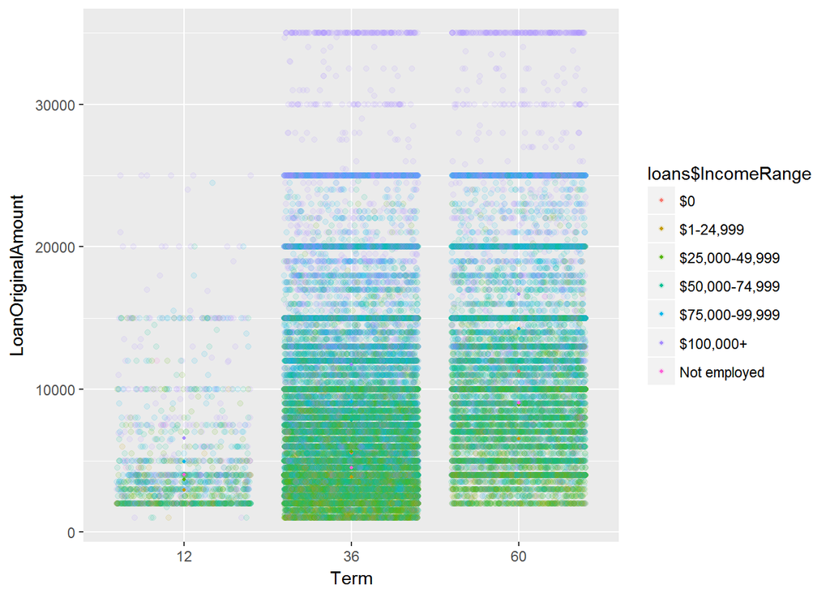

Looking at the data, a few things stand out. First, the middle term, 36 months, actually has the lowest minimum original loan amount. Second, borrowers with $100k+ in income are much more likely to borrow on a term of 36 or 60 months. Additionally, the shortest loan, 12 months, is not very popular across income brackets.

Next let’s dive into `ProsperScore` vs. `LoanOriginalAmount` cut by `IncomeRange` to understand whether the relationship between the two former variables changes as income changes:

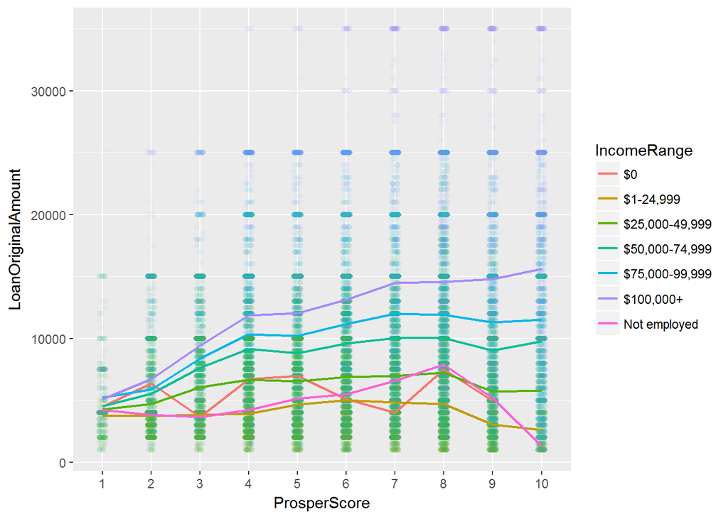

A few interesting things emerge from this visualization. First, we see that original loan amount seems to have a clear positive correlation with `ProsperScore` for incomes above $50k, and particularly those above $100k. Conversely, for income levels below $50k, there seems to be almost no correlation. It is possible that it is these borrowers’ lower income levels that is causing Prosper to lend smaller amounts, irrespective of their quality score. On the other hand, it could be that borrowers with lower incomes simply need to borrow less. Ultimately, this analysis only allows us to comment on correlation, not causation.

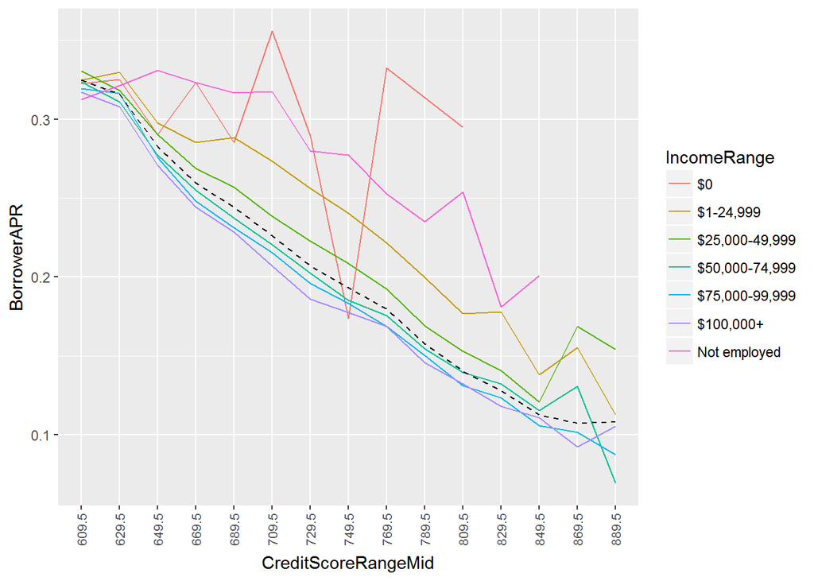

As we can see, `BorrowerAPR` generally decreases as `CreditScoreRangeMid` increases for all income types, but there are a few things of note. First, the APR decreases more slowly for “Not employed” borrowers than other types of borrowers who have a positive income, even as their credit score increases. Perhaps Prosper views the lack of employment as more reflective of risk than credit score and prices the loan accordingly. Secondly, we see that users who report no income do not see much increase in APR as their credit rate increases. That said, we only have 45 data points in our sample for which the borrower’s income was $0, so we should refrain from drawing any meaningful conclusions from that data.

# Multivariate Analysis

### Talk about some of the relationships you observed in this part of the investigation. Were there features that strengthened each other in terms of looking at your feature(s) of interest?

In this section, I primarily looked at `LoanOriginalAmount`, `IncomeRange`, and `ProsperScore`. Additionally, I looked into `Term` and `BorrowerAPR`. Specifically, controlling for `IncomeRange` seemed to strengthen the relationship between different pairs of variables.

### Were there any interesting or surprising interactions between features?

First, I was very surprised to see that `LoanOriginalAmount` did not materially increase as `ProsperScore` increased for those who were unemployed or had low incomes. I had expected that the loan amount would increase along with `ProsperScore` despite the borrower’s income. Second, it was quite interesting how `IncomeRange` affected the relationship between APR and credit score. In particular, I was surprised to see how much unemployment or a reported income of zero drove up the APR, all else equal.

# Final Plots and Summary

### Plot One

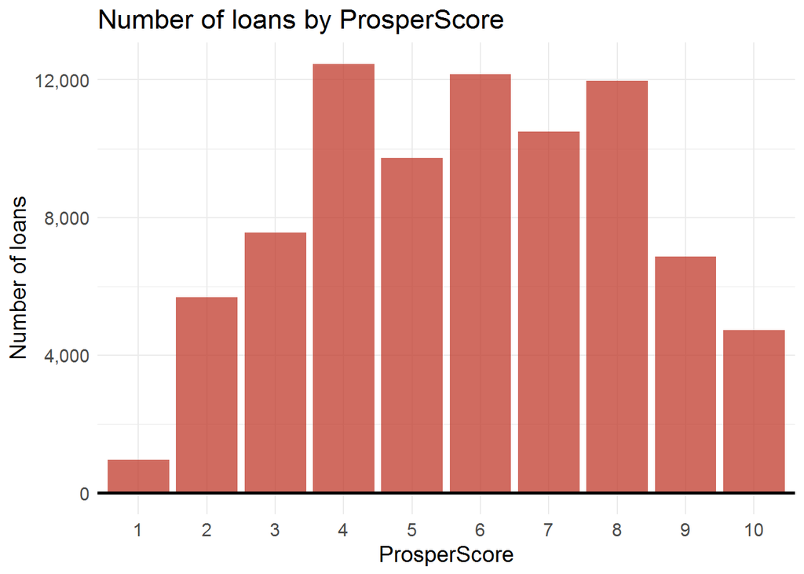

### Description One

There is a somewhat normal distribution of `ProsperScore` with the bulk of the loans receiving scores between 4 and 8. Interestingly, the score least present in the data set is 1. This makes sense as it is unlikely Proper would want to initiate many loans with such a low score.

### Plot Two

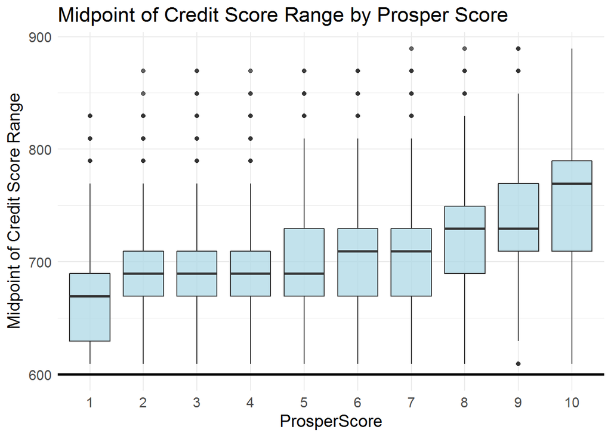

### Description Two

The borrower’s credit score is clearly associated with higher Prosper loan scores as we see based on the upwards trend in the data. Interestingly, there are more high-score outliers among loans with a lower `ProsperScore`. What this tells me is that it’s more common to get a low `ProsperScore` despite a very high credit score than to get a high `ProsperScore` with a very low credit score.

### Plot Three

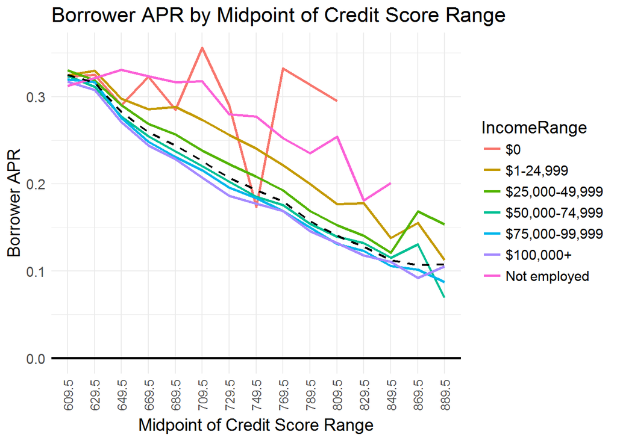

### Description Three

There’s a very clear negative relationship between the APR a borrower receives and his or her credit score. What’s most interesting about this chart is that the strength of the relationship is lower for some income levels, including most notably `$0` and `Not employed`. This makes sense as borrowers with a high credit score are likely the most trustworthy borrowers and least likely to default. As a result, lenders compete for these borrowers, driving the APR down.

# Reflection

The Prosper loans data set contains over 100,000 loans with more than 80 variables each. One of the struggles I had is that there were not as many continuous variables of interest as I initially expected. As a result, I had to convert a few variables from factor to numeric and back, including `CreditScoreRangeMid` and `ProsperScore`. Additionally, I faced a few data quality issues. First, the `ProsperScore` field included some values of `11`, which exceeded what was allowed according to the data dictionary. Additionally, `AmountDelinquent` seemed to have a massive outlier, so I was forced to remove that as well. Finally, another major challenge I encountered was the use of `ggpairs()`. Because I included so many variables, the notebook took a long time to execute and knit and the resulting axes and charts were hard to read.

On the flip side, the use of `ggpairs()` did provide evidence of interesting correlations that I explored later on in my analysis, including that of `BorrowerAPR` vs. `CreditScoreRangeMid`. Through looking at this relationship, I was able to clearly see how income range layers on top of credit score to influence Prosper’s score of the line. Additionally, I had the opportunity to learn and use new functionality as part of the `ggplot2` package, including labeling axes and plots, using different themes, and rotating my axis labels.

With additional time, regression modeling could be used to determine which input variables have the strongest impact on a pre-determined output variable. Furthermore, a machine learning model could be built to automatically score future loan applications based on the learnings from this data set.